# Lab Case Study

### Importing relevant libraries / modules

```python
import pandas as pd
import numpy as np
import matplotlib.pyplot as plt
import seaborn as sns
```

### Importing and merging files

```python
file1 = pd.read_csv('Data/file1.csv')
file2 = pd.read_csv('Data/file2.csv')
file3 = pd.read_csv('Data/file3.csv')
```

```python
file1
```

|  | Customer | ST | GENDER | Education | Customer Lifetime Value | Income | Monthly Premium Auto | Number of Open Complaints | Policy Type | Vehicle Class | Total Claim Amount |
| --- | --- | --- | --- | --- | --- | --- | --- | --- | --- | --- | --- |
| 0 | RB50392 | Washington | NaN | Master | NaN | 0.0 | 1000.0 | 1/0/00 | Personal Auto | Four-Door Car | 2.704934 |
| 1 | QZ44356 | Arizona | F | Bachelor | 697953.59% | 0.0 | 94.0 | 1/0/00 | Personal Auto | Four-Door Car | 1131.464935 |
| 2 | AI49188 | Nevada | F | Bachelor | 1288743.17% | 48767.0 | 108.0 | 1/0/00 | Personal Auto | Two-Door Car | 566.472247 |
| 3 | WW63253 | California | M | Bachelor | 764586.18% | 0.0 | 106.0 | 1/0/00 | Corporate Auto | SUV | 529.881344 |
| 4 | GA49547 | Washington | M | High School or Below | 536307.65% | 36357.0 | 68.0 | 1/0/00 | Personal Auto | Four-Door Car | 17.269323 |
| ... | ... | ... | ... | ... | ... | ... | ... | ... | ... | ... | ... |
| 4003 | NaN | NaN | NaN | NaN | NaN | NaN | NaN | NaN | NaN | NaN | NaN |
| 4004 | NaN | NaN | NaN | NaN | NaN | NaN | NaN | NaN | NaN | NaN | NaN |
| 4005 | NaN | NaN | NaN | NaN | NaN | NaN | NaN | NaN | NaN | NaN | NaN |
| 4006 | NaN | NaN | NaN | NaN | NaN | NaN | NaN | NaN | NaN | NaN | NaN |
| 4007 | NaN | NaN | NaN | NaN | NaN | NaN | NaN | NaN | NaN | NaN | NaN |

4008 rows × 11 columns

```python
file2
```

|  | Customer | ST | GENDER | Education | Customer Lifetime Value | Income | Monthly Premium Auto | Number of Open Complaints | Total Claim Amount | Policy Type | Vehicle Class |
| --- | --- | --- | --- | --- | --- | --- | --- | --- | --- | --- | --- |
| 0 | GS98873 | Arizona | F | Bachelor | 323912.47% | 16061 | 88 | 1/0/00 | 633.600000 | Personal Auto | Four-Door Car |
| 1 | CW49887 | California | F | Master | 462680.11% | 79487 | 114 | 1/0/00 | 547.200000 | Special Auto | SUV |
| 2 | MY31220 | California | F | College | 899704.02% | 54230 | 112 | 1/0/00 | 537.600000 | Personal Auto | Two-Door Car |
| 3 | UH35128 | Oregon | F | College | 2580706.30% | 71210 | 214 | 1/1/00 | 1027.200000 | Personal Auto | Luxury Car |
| 4 | WH52799 | Arizona | F | College | 380812.21% | 94903 | 94 | 1/0/00 | 451.200000 | Corporate Auto | Two-Door Car |
| ... | ... | ... | ... | ... | ... | ... | ... | ... | ... | ... | ... |
| 991 | HV85198 | Arizona | M | Master | 847141.75% | 63513 | 70 | 1/0/00 | 185.667213 | Personal Auto | Four-Door Car |
| 992 | BS91566 | Arizona | F | College | 543121.91% | 58161 | 68 | 1/0/00 | 140.747286 | Corporate Auto | Four-Door Car |
| 993 | IL40123 | Nevada | F | College | 568964.41% | 83640 | 70 | 1/0/00 | 471.050488 | Corporate Auto | Two-Door Car |
| 994 | MY32149 | California | F | Master | 368672.38% | 0 | 96 | 1/0/00 | 28.460568 | Personal Auto | Two-Door Car |
| 995 | SA91515 | California | M | Bachelor | 399258.39% | 0 | 111 | 1/0/00 | 700.349052 | Personal Auto | SUV |

996 rows × 11 columns

```python
file3
```

|  | Customer | State | Customer Lifetime Value | Education | Gender | Income | Monthly Premium Auto | Number of Open Complaints | Policy Type | Total Claim Amount | Vehicle Class |
| --- | --- | --- | --- | --- | --- | --- | --- | --- | --- | --- | --- |
| 0 | SA25987 | Washington | 3479.137523 | High School or Below | M | 0 | 104 | 0 | Personal Auto | 499.200000 | Two-Door Car |
| 1 | TB86706 | Arizona | 2502.637401 | Master | M | 0 | 66 | 0 | Personal Auto | 3.468912 | Two-Door Car |
| 2 | ZL73902 | Nevada | 3265.156348 | Bachelor | F | 25820 | 82 | 0 | Personal Auto | 393.600000 | Four-Door Car |
| 3 | KX23516 | California | 4455.843406 | High School or Below | F | 0 | 121 | 0 | Personal Auto | 699.615192 | SUV |
| 4 | FN77294 | California | 7704.958480 | High School or Below | M | 30366 | 101 | 2 | Personal Auto | 484.800000 | SUV |
| ... | ... | ... | ... | ... | ... | ... | ... | ... | ... | ... | ... |
| 7065 | LA72316 | California | 23405.987980 | Bachelor | M | 71941 | 73 | 0 | Personal Auto | 198.234764 | Four-Door Car |
| 7066 | PK87824 | California | 3096.511217 | College | F | 21604 | 79 | 0 | Corporate Auto | 379.200000 | Four-Door Car |
| 7067 | TD14365 | California | 8163.890428 | Bachelor | M | 0 | 85 | 3 | Corporate Auto | 790.784983 | Four-Door Car |
| 7068 | UP19263 | California | 7524.442436 | College | M | 21941 | 96 | 0 | Personal Auto | 691.200000 | Four-Door Car |
| 7069 | Y167826 | California | 2611.836866 | College | M | 0 | 77 | 0 | Corporate Auto | 369.600000 | Two-Door Car |

7070 rows × 11 columns

**Some observations about the files:**

1. It seems like 'file1' has a lot of rows with only `NaN` values. We can get rid of them.
2. 'file3' has different column names compared to the other files, what would cause trouble when concatenating.

```python
#1. delete rows only if ALL values are missing
file1.dropna(axis=0, how='all', inplace=True)
file1.shape
```

```
(1071, 11)
```

```python
#2. rename columns in file3 to match the ones in the other files
file3.rename(columns={'State': 'ST', 'Gender': 'GENDER'}, inplace=True)
file3.columns
```

```
Index(['Customer', 'ST', 'Customer Lifetime Value', 'Education', 'GENDER',
       'Income', 'Monthly Premium Auto', 'Number of Open Complaints',
       'Policy Type', 'Total Claim Amount', 'Vehicle Class'],
      dtype='object')
```

```python
customer_data = pd.concat([file1, file2, file3]).reset_index(drop=True)
customer_data
```

|  | Customer | ST | GENDER | Education | Customer Lifetime Value | Income | Monthly Premium Auto | Number of Open Complaints | Policy Type | Vehicle Class | Total Claim Amount |
| --- | --- | --- | --- | --- | --- | --- | --- | --- | --- | --- | --- |
| 0 | RB50392 | Washington | NaN | Master | NaN | 0.0 | 1000.0 | 1/0/00 | Personal Auto | Four-Door Car | 2.704934 |
| 1 | QZ44356 | Arizona | F | Bachelor | 697953.59% | 0.0 | 94.0 | 1/0/00 | Personal Auto | Four-Door Car | 1131.464935 |
| 2 | AI49188 | Nevada | F | Bachelor | 1288743.17% | 48767.0 | 108.0 | 1/0/00 | Personal Auto | Two-Door Car | 566.472247 |
| 3 | WW63253 | California | M | Bachelor | 764586.18% | 0.0 | 106.0 | 1/0/00 | Corporate Auto | SUV | 529.881344 |
| 4 | GA49547 | Washington | M | High School or Below | 536307.65% | 36357.0 | 68.0 | 1/0/00 | Personal Auto | Four-Door Car | 17.269323 |
| ... | ... | ... | ... | ... | ... | ... | ... | ... | ... | ... | ... |
| 9132 | LA72316 | California | M | Bachelor | 23405.98798 | 71941.0 | 73.0 | 0 | Personal Auto | Four-Door Car | 198.234764 |
| 9133 | PK87824 | California | F | College | 3096.511217 | 21604.0 | 79.0 | 0 | Corporate Auto | Four-Door Car | 379.200000 |
| 9134 | TD14365 | California | M | Bachelor | 8163.890428 | 0.0 | 85.0 | 3 | Corporate Auto | Four-Door Car | 790.784983 |
| 9135 | UP19263 | California | M | College | 7524.442436 | 21941.0 | 96.0 | 0 | Personal Auto | Four-Door Car | 691.200000 |
| 9136 | Y167826 | California | M | College | 2611.836866 | 0.0 | 77.0 | 0 | Corporate Auto | Two-Door Car | 369.600000 |

9137 rows × 11 columns

Let's investigate the data a bit further.

```python
customer_data.nunique()
```

```
Customer                     9056
ST                              8
GENDER                          5
Education                       6
Customer Lifetime Value      8211
Income                       5655
Monthly Premium Auto          209
Number of Open Complaints      12
Policy Type                     3
Vehicle Class                   6
Total Claim Amount           5070
dtype: int64
```

```python
customer_data.info()
```

```
<class 'pandas.core.frame.DataFrame'>
RangeIndex: 9137 entries, 0 to 9136
Data columns (total 11 columns):
 #   Column                     Non-Null Count  Dtype
---  ------                     --------------  -----
 0   Customer                   9137 non-null   object
 1   ST                         9137 non-null   object
 2   GENDER                     9015 non-null   object
 3   Education                  9137 non-null   object
 4   Customer Lifetime Value    9130 non-null   object
 5   Income                     9137 non-null   float64
 6   Monthly Premium Auto       9137 non-null   float64
 7   Number of Open Complaints  9137 non-null   object
 8   Policy Type                9137 non-null   object
 9   Vehicle Class              9137 non-null   object
 10  Total Claim Amount         9137 non-null   float64
dtypes: float64(3), object(8)
memory usage: 785.3+ KB
```

**More observations about the data**

- Header names have different naming conventions
- For analysis purposes, the Customer column doesn't add any useful information
- GENDER has more unique values than expected
- The columns Customer Lifetime Value and Number of Open Complaints have inconsistent values and 'object' as data type, when they were suposed to be 'numeric'
- Only two columns have missing values: GENDER and Customer Lifetime Value

### Standardizing header names

```python
# change the columns to lower case and snake case (with an underscore)
customer_data.columns = customer_data.columns.str.lower().str.replace(' ', '_')

# change the column 'st' to a more intuitive name
customer_data.rename(columns={'st': 'state'}, inplace=True)

customer_data
```

|  | customer | state | gender | education | customer_lifetime_value | income | monthly_premium_auto | number_of_open_complaints | policy_type | vehicle_class | total_claim_amount |
| --- | --- | --- | --- | --- | --- | --- | --- | --- | --- | --- | --- |
| 0 | RB50392 | Washington | NaN | Master | NaN | 0.0 | 1000.0 | 1/0/00 | Personal Auto | Four-Door Car | 2.704934 |
| 1 | QZ44356 | Arizona | F | Bachelor | 697953.59% | 0.0 | 94.0 | 1/0/00 | Personal Auto | Four-Door Car | 1131.464935 |
| 2 | AI49188 | Nevada | F | Bachelor | 1288743.17% | 48767.0 | 108.0 | 1/0/00 | Personal Auto | Two-Door Car | 566.472247 |
| 3 | WW63253 | California | M | Bachelor | 764586.18% | 0.0 | 106.0 | 1/0/00 | Corporate Auto | SUV | 529.881344 |
| 4 | GA49547 | Washington | M | High School or Below | 536307.65% | 36357.0 | 68.0 | 1/0/00 | Personal Auto | Four-Door Car | 17.269323 |
| ... | ... | ... | ... | ... | ... | ... | ... | ... | ... | ... | ... |
| 9132 | LA72316 | California | M | Bachelor | 23405.98798 | 71941.0 | 73.0 | 0 | Personal Auto | Four-Door Car | 198.234764 |
| 9133 | PK87824 | California | F | College | 3096.511217 | 21604.0 | 79.0 | 0 | Corporate Auto | Four-Door Car | 379.200000 |
| 9134 | TD14365 | California | M | Bachelor | 8163.890428 | 0.0 | 85.0 | 3 | Corporate Auto | Four-Door Car | 790.784983 |
| 9135 | UP19263 | California | M | College | 7524.442436 | 21941.0 | 96.0 | 0 | Personal Auto | Four-Door Car | 691.200000 |
| 9136 | Y167826 | California | M | College | 2611.836866 | 0.0 | 77.0 | 0 | Corporate Auto | Two-Door Car | 369.600000 |

9137 rows × 11 columns

### Deleting unecessary columns

```python
customer_data.drop('customer', axis=1, inplace=True)
```

```python
customer_data
```

|  | state | gender | education | customer_lifetime_value | income | monthly_premium_auto | number_of_open_complaints | policy_type | vehicle_class | total_claim_amount |
| --- | --- | --- | --- | --- | --- | --- | --- | --- | --- | --- |
| 0 | Washington | NaN | Master | NaN | 0.0 | 1000.0 | 1/0/00 | Personal Auto | Four-Door Car | 2.704934 |
| 1 | Arizona | F | Bachelor | 697953.59% | 0.0 | 94.0 | 1/0/00 | Personal Auto | Four-Door Car | 1131.464935 |
| 2 | Nevada | F | Bachelor | 1288743.17% | 48767.0 | 108.0 | 1/0/00 | Personal Auto | Two-Door Car | 566.472247 |
| 3 | California | M | Bachelor | 764586.18% | 0.0 | 106.0 | 1/0/00 | Corporate Auto | SUV | 529.881344 |
| 4 | Washington | M | High School or Below | 536307.65% | 36357.0 | 68.0 | 1/0/00 | Personal Auto | Four-Door Car | 17.269323 |
| ... | ... | ... | ... | ... | ... | ... | ... | ... | ... | ... |
| 9132 | California | M | Bachelor | 23405.98798 | 71941.0 | 73.0 | 0 | Personal Auto | Four-Door Car | 198.234764 |
| 9133 | California | F | College | 3096.511217 | 21604.0 | 79.0 | 0 | Corporate Auto | Four-Door Car | 379.200000 |
| 9134 | California | M | Bachelor | 8163.890428 | 0.0 | 85.0 | 3 | Corporate Auto | Four-Door Car | 790.784983 |
| 9135 | California | M | College | 7524.442436 | 21941.0 | 96.0 | 0 | Personal Auto | Four-Door Car | 691.200000 |
| 9136 | California | M | College | 2611.836866 | 0.0 | 77.0 | 0 | Corporate Auto | Two-Door Car | 369.600000 |

9137 rows × 10 columns

### Filtering data and correcting typos

**state**

```python
# check the values in the 'state' column
customer_data['state'].value_counts(dropna=False)
```

```
California    3032
Oregon        2601
Arizona       1630
Nevada         882
Washington     768
Cali           120
AZ              74
WA              30
Name: state, dtype: int64
```

```python
customer_data['state'].replace({'Cali': 'California', 'AZ': 'Arizona', 'WA': 'Washington'}, inplace=True)
customer_data['state'].value_counts()
```

```
California    3152
Oregon        2601
Arizona       1704
Nevada         882
Washington     798
Name: state, dtype: int64
```

**gender**

```python
# check the values in the 'gender' column
customer_data['gender'].value_counts(dropna=False)
```

```
F         4560
M         4368
NaN        122
Male        40
female      30
Femal       17
Name: gender, dtype: int64
```

```python
customer_data['gender'].replace({'Male': 'M', 'Femal': 'F', 'female': 'F'}, inplace=True)
customer_data['gender'].value_counts(dropna=False)
```

```
F      4607
M      4408
NaN     122
Name: gender, dtype: int64
```

**education**

```python
customer_data['education'].value_counts()
```

```
Bachelor                2719
College                 2682
High School or Below    2616
Master                   752
Doctor                   344
Bachelors                 24
Name: education, dtype: int64
```

```python
# Just a small issue regarding 'Bachelor/s'
customer_data['education'].replace('Bachelors', 'Bachelor', inplace=True)
customer_data['education'].value_counts(dropna=False)
```

```
Bachelor                2743
College                 2682
High School or Below    2616
Master                   752
Doctor                   344
Name: education, dtype: int64
```

### Correcting data types

**customer_lifetime_value**

```python
# check if string has anything that is not a number
customer_data['customer_lifetime_value'].str.contains('(?!^\d+$)^.+$').sum()
```

```
2060
```

```python
customer_data['customer_lifetime_value'].str.contains('%').sum()
```

```
2060
```

```python
remove_pct = lambda x: x.replace('%', '') if type(x) == str else x
customer_data['customer_lifetime_value'] = customer_data['customer_lifetime_value'].apply(remove_pct)
```

```python
customer_data['customer_lifetime_value'] = customer_data['customer_lifetime_value'].astype(float)
customer_data['customer_lifetime_value']
```

```
0                NaN
1       6.979536e+05
2       1.288743e+06
3       7.645862e+05
4       5.363077e+05
            ...
9132    2.340599e+04
9133    3.096511e+03
9134    8.163890e+03
9135    7.524442e+03
9136    2.611837e+03
Name: customer_lifetime_value, Length: 9137, dtype: float64
```

**number_of_open_complaints**

```python
customer_data['number_of_open_complaints'].value_counts()
```

```
0         5629
1/0/00    1626
1          765
2          283
1/1/00     247
3          230
4          119
1/2/00      93
1/3/00      60
5           44
1/4/00      29
1/5/00      12
Name: number_of_open_complaints, dtype: int64
```

```python
get_middle_number = lambda x: x.split('/')[1] if type(x) == str else x
# We only want to modify the values stored as strings. By splitting them, we should get the numbers stored as a list
# and we are interested in the second element (index 1)

customer_data['number_of_open_complaints'] = customer_data['number_of_open_complaints'].apply(get_middle_number).astype(int)
customer_data['number_of_open_complaints'].value_counts()
```

```
0    7255
1    1012
2     376
3     290
4     148
5      56
Name: number_of_open_complaints, dtype: int64
```

Check if we have the right types:

```python
customer_data.info()
```

```
<class 'pandas.core.frame.DataFrame'>
RangeIndex: 9137 entries, 0 to 9136
Data columns (total 10 columns):
 #   Column                     Non-Null Count  Dtype
---  ------                     --------------  -----
 0   state                      9137 non-null   object
 1   gender                     9015 non-null   object
 2   education                  9137 non-null   object
 3   customer_lifetime_value    9130 non-null   float64
 4   income                     9137 non-null   float64
 5   monthly_premium_auto       9137 non-null   float64
 6   number_of_open_complaints  9137 non-null   int32
 7   policy_type                9137 non-null   object
 8   vehicle_class              9137 non-null   object
 9   total_claim_amount         9137 non-null   float64
dtypes: float64(4), int32(1), object(5)
memory usage: 678.3+ KB
```

### Removing duplicates

```python
customer_data.drop_duplicates(inplace=True)
customer_data
```

|  | state | gender | education | customer_lifetime_value | income | monthly_premium_auto | number_of_open_complaints | policy_type | vehicle_class | total_claim_amount |
| --- | --- | --- | --- | --- | --- | --- | --- | --- | --- | --- |
| 0 | Washington | NaN | Master | NaN | 0.0 | 1000.0 | 0 | Personal Auto | Four-Door Car | 2.704934 |
| 1 | Arizona | F | Bachelor | 6.979536e+05 | 0.0 | 94.0 | 0 | Personal Auto | Four-Door Car | 1131.464935 |
| 2 | Nevada | F | Bachelor | 1.288743e+06 | 48767.0 | 108.0 | 0 | Personal Auto | Two-Door Car | 566.472247 |
| 3 | California | M | Bachelor | 7.645862e+05 | 0.0 | 106.0 | 0 | Corporate Auto | SUV | 529.881344 |
| 4 | Washington | M | High School or Below | 5.363077e+05 | 36357.0 | 68.0 | 0 | Personal Auto | Four-Door Car | 17.269323 |
| ... | ... | ... | ... | ... | ... | ... | ... | ... | ... | ... |
| 9132 | California | M | Bachelor | 2.340599e+04 | 71941.0 | 73.0 | 0 | Personal Auto | Four-Door Car | 198.234764 |
| 9133 | California | F | College | 3.096511e+03 | 21604.0 | 79.0 | 0 | Corporate Auto | Four-Door Car | 379.200000 |
| 9134 | California | M | Bachelor | 8.163890e+03 | 0.0 | 85.0 | 3 | Corporate Auto | Four-Door Car | 790.784983 |
| 9135 | California | M | College | 7.524442e+03 | 21941.0 | 96.0 | 0 | Personal Auto | Four-Door Car | 691.200000 |
| 9136 | California | M | College | 2.611837e+03 | 0.0 | 77.0 | 0 | Corporate Auto | Two-Door Car | 369.600000 |

8875 rows × 10 columns

### Replacing null values

The only numeric column with missing values is customer_lifetime_value. We're gonna replace those with the mean.

```python
customer_data['customer_lifetime_value'].fillna(customer_data['customer_lifetime_value'].mean(), inplace=True)
customer_data['customer_lifetime_value'].isna().sum()
```

```
0
```

For the gender column, let's adopt 'unknown' for the missing values

```python
customer_data['gender'].fillna('Unknown', inplace=True)
customer_data['customer_lifetime_value'].isna().sum()
```

```
0
```

```python
customer_data.reset_index(drop=True, inplace=True)
customer_data
```

|  | state | gender | education | customer_lifetime_value | income | monthly_premium_auto | number_of_open_complaints | policy_type | vehicle_class | total_claim_amount |
| --- | --- | --- | --- | --- | --- | --- | --- | --- | --- | --- |
| 0 | Washington | Unknown | Master | 1.855902e+05 | 0.0 | 1000.0 | 0 | Personal Auto | Four-Door Car | 2.704934 |
| 1 | Arizona | F | Bachelor | 6.979536e+05 | 0.0 | 94.0 | 0 | Personal Auto | Four-Door Car | 1131.464935 |
| 2 | Nevada | F | Bachelor | 1.288743e+06 | 48767.0 | 108.0 | 0 | Personal Auto | Two-Door Car | 566.472247 |
| 3 | California | M | Bachelor | 7.645862e+05 | 0.0 | 106.0 | 0 | Corporate Auto | SUV | 529.881344 |
| 4 | Washington | M | High School or Below | 5.363077e+05 | 36357.0 | 68.0 | 0 | Personal Auto | Four-Door Car | 17.269323 |
| ... | ... | ... | ... | ... | ... | ... | ... | ... | ... | ... |
| 8870 | California | M | Bachelor | 2.340599e+04 | 71941.0 | 73.0 | 0 | Personal Auto | Four-Door Car | 198.234764 |
| 8871 | California | F | College | 3.096511e+03 | 21604.0 | 79.0 | 0 | Corporate Auto | Four-Door Car | 379.200000 |
| 8872 | California | M | Bachelor | 8.163890e+03 | 0.0 | 85.0 | 3 | Corporate Auto | Four-Door Car | 790.784983 |
| 8873 | California | M | College | 7.524442e+03 | 21941.0 | 96.0 | 0 | Personal Auto | Four-Door Car | 691.200000 |
| 8874 | California | M | College | 2.611837e+03 | 0.0 | 77.0 | 0 | Corporate Auto | Two-Door Car | 369.600000 |

8875 rows × 10 columns

### Bucketing the data

```python
customer_data['zones'] = customer_data['state'].replace({
    'California': 'West Region',
    'Oregon': 'North West',
    'Washington': 'East',
    'Arizona': 'Central',
    'Nevada': 'Central'
})
customer_data
```

|  | state | gender | education | customer_lifetime_value | income | monthly_premium_auto | number_of_open_complaints | policy_type | vehicle_class | total_claim_amount | zones |
| --- | --- | --- | --- | --- | --- | --- | --- | --- | --- | --- | --- |
| 0 | Washington | Unknown | Master | 1.855902e+05 | 0.0 | 1000.0 | 0 | Personal Auto | Four-Door Car | 2.704934 | East |
| 1 | Arizona | F | Bachelor | 6.979536e+05 | 0.0 | 94.0 | 0 | Personal Auto | Four-Door Car | 1131.464935 | Central |
| 2 | Nevada | F | Bachelor | 1.288743e+06 | 48767.0 | 108.0 | 0 | Personal Auto | Two-Door Car | 566.472247 | Central |
| 3 | California | M | Bachelor | 7.645862e+05 | 0.0 | 106.0 | 0 | Corporate Auto | SUV | 529.881344 | West Region |
| 4 | Washington | M | High School or Below | 5.363077e+05 | 36357.0 | 68.0 | 0 | Personal Auto | Four-Door Car | 17.269323 | East |
| ... | ... | ... | ... | ... | ... | ... | ... | ... | ... | ... | ... |
| 8870 | California | M | Bachelor | 2.340599e+04 | 71941.0 | 73.0 | 0 | Personal Auto | Four-Door Car | 198.234764 | West Region |
| 8871 | California | F | College | 3.096511e+03 | 21604.0 | 79.0 | 0 | Corporate Auto | Four-Door Car | 379.200000 | West Region |
| 8872 | California | M | Bachelor | 8.163890e+03 | 0.0 | 85.0 | 3 | Corporate Auto | Four-Door Car | 790.784983 | West Region |
| 8873 | California | M | College | 7.524442e+03 | 21941.0 | 96.0 | 0 | Personal Auto | Four-Door Car | 691.200000 | West Region |
| 8874 | California | M | College | 2.611837e+03 | 0.0 | 77.0 | 0 | Corporate Auto | Two-Door Car | 369.600000 | West Region |

8875 rows × 11 columns

### Categorical and numerical columns

```python
categorical_columns = customer_data.columns[customer_data.dtypes == 'object'].to_list()
categorical_columns
```

```
['state', 'gender', 'education', 'policy_type', 'vehicle_class', 'zones']
```

```python
numerical_columns = customer_data.columns[customer_data.dtypes != 'object'].to_list()
numerical_columns
```

```
['customer_lifetime_value',
 'income',
 'monthly_premium_auto',
 'number_of_open_complaints',
 'total_claim_amount']
```

### Standardizing the data

```python
customer_data[categorical_columns] = customer_data[categorical_columns].applymap(str.lower)
customer_data[categorical_columns]
```

|  | state | gender | education | policy_type | vehicle_class | zones |
| --- | --- | --- | --- | --- | --- | --- |
| 0 | washington | unknown | master | personal auto | four-door car | east |
| 1 | arizona | f | bachelor | personal auto | four-door car | central |
| 2 | nevada | f | bachelor | personal auto | two-door car | central |
| 3 | california | m | bachelor | corporate auto | suv | west region |
| 4 | washington | m | high school or below | personal auto | four-door car | east |
| ... | ... | ... | ... | ... | ... | ... |
| 8870 | california | m | bachelor | personal auto | four-door car | west region |
| 8871 | california | f | college | corporate auto | four-door car | west region |
| 8872 | california | m | bachelor | corporate auto | four-door car | west region |
| 8873 | california | m | college | personal auto | four-door car | west region |
| 8874 | california | m | college | corporate auto | two-door car | west region |

8875 rows × 6 columns

**We have a new dataset to work with!**

```python
new_customer_data = pd.read_csv('Data/Data_Marketing_Customer_Analysis_Round2.csv')
new_customer_data
```

|  | Unnamed: 0 | Customer | State | Customer Lifetime Value | Response | Coverage | Education | Effective To Date | EmploymentStatus | Gender | ... | Number of Open Complaints | Number of Policies | Policy Type | Policy | Renew Offer Type | Sales Channel | Total Claim Amount | Vehicle Class | Vehicle Size | Vehicle Type |
| --- | --- | --- | --- | --- | --- | --- | --- | --- | --- | --- | --- | --- | --- | --- | --- | --- | --- | --- | --- | --- | --- |
| 0 | 0 | DK49336 | Arizona | 4809.216960 | No | Basic | College | 2/18/11 | Employed | M | ... | 0.0 | 9 | Corporate Auto | Corporate L3 | Offer3 | Agent | 292.800000 | Four-Door Car | Medsize | NaN |
| 1 | 1 | KX64629 | California | 2228.525238 | No | Basic | College | 1/18/11 | Unemployed | F | ... | 0.0 | 1 | Personal Auto | Personal L3 | Offer4 | Call Center | 744.924331 | Four-Door Car | Medsize | NaN |
| 2 | 2 | LZ68649 | Washington | 14947.917300 | No | Basic | Bachelor | 2/10/11 | Employed | M | ... | 0.0 | 2 | Personal Auto | Personal L3 | Offer3 | Call Center | 480.000000 | SUV | Medsize | A |
| 3 | 3 | XL78013 | Oregon | 22332.439460 | Yes | Extended | College | 1/11/11 | Employed | M | ... | 0.0 | 2 | Corporate Auto | Corporate L3 | Offer2 | Branch | 484.013411 | Four-Door Car | Medsize | A |
| 4 | 4 | QA50777 | Oregon | 9025.067525 | No | Premium | Bachelor | 1/17/11 | Medical Leave | F | ... | NaN | 7 | Personal Auto | Personal L2 | Offer1 | Branch | 707.925645 | Four-Door Car | Medsize | NaN |
| ... | ... | ... | ... | ... | ... | ... | ... | ... | ... | ... | ... | ... | ... | ... | ... | ... | ... | ... | ... | ... | ... |
| 10905 | 10905 | FE99816 | Nevada | 15563.369440 | No | Premium | Bachelor | 1/19/11 | Unemployed | F | ... | NaN | 7 | Personal Auto | Personal L1 | Offer3 | Web | 1214.400000 | Luxury Car | Medsize | A |
| 10906 | 10906 | KX53892 | Oregon | 5259.444853 | No | Basic | College | 1/6/11 | Employed | F | ... | 0.0 | 6 | Personal Auto | Personal L3 | Offer2 | Branch | 273.018929 | Four-Door Car | Medsize | A |
| 10907 | 10907 | TL39050 | Arizona | 23893.304100 | No | Extended | Bachelor | 2/6/11 | Employed | F | ... | 0.0 | 2 | Corporate Auto | Corporate L3 | Offer1 | Web | 381.306996 | Luxury SUV | Medsize | NaN |
| 10908 | 10908 | WA60547 | California | 11971.977650 | No | Premium | College | 2/13/11 | Employed | F | ... | 4.0 | 6 | Personal Auto | Personal L1 | Offer1 | Branch | 618.288849 | SUV | Medsize | A |
| 10909 | 10909 | IV32877 | NaN | 6857.519928 | NaN | Basic | Bachelor | 1/8/11 | Unemployed | M | ... | 0.0 | 3 | Personal Auto | Personal L1 | Offer4 | Web | 1021.719397 | SUV | Medsize | NaN |

10910 rows × 26 columns

```python
new_customer_data.isna().sum()
```

```
Unnamed: 0                          0
Customer                            0
State                             631
Customer Lifetime Value             0
Response                          631
Coverage                            0
Education                           0
Effective To Date                   0
EmploymentStatus                    0
Gender                              0
Income                              0
Location Code                       0
Marital Status                      0
Monthly Premium Auto                0
Months Since Last Claim           633
Months Since Policy Inception       0
Number of Open Complaints         633
Number of Policies                  0
Policy Type                         0
Policy                              0
Renew Offer Type                    0
Sales Channel                       0
Total Claim Amount                  0
Vehicle Class                     622
Vehicle Size                      622
Vehicle Type                     5482
dtype: int64
```

```python
new_customer_data.drop(columns=['Unnamed: 0', 'Customer', 'Vehicle Type'], axis=1, inplace=True)
new_customer_data
```

|  | State | Customer Lifetime Value | Response | Coverage | Education | Effective To Date | EmploymentStatus | Gender | Income | Location Code | ... | Months Since Policy Inception | Number of Open Complaints | Number of Policies | Policy Type | Policy | Renew Offer Type | Sales Channel | Total Claim Amount | Vehicle Class | Vehicle Size |
| --- | --- | --- | --- | --- | --- | --- | --- | --- | --- | --- | --- | --- | --- | --- | --- | --- | --- | --- | --- | --- | --- |
| 0 | Arizona | 4809.216960 | No | Basic | College | 2/18/11 | Employed | M | 48029 | Suburban | ... | 52 | 0.0 | 9 | Corporate Auto | Corporate L3 | Offer3 | Agent | 292.800000 | Four-Door Car | Medsize |
| 1 | California | 2228.525238 | No | Basic | College | 1/18/11 | Unemployed | F | 0 | Suburban | ... | 26 | 0.0 | 1 | Personal Auto | Personal L3 | Offer4 | Call Center | 744.924331 | Four-Door Car | Medsize |
| 2 | Washington | 14947.917300 | No | Basic | Bachelor | 2/10/11 | Employed | M | 22139 | Suburban | ... | 31 | 0.0 | 2 | Personal Auto | Personal L3 | Offer3 | Call Center | 480.000000 | SUV | Medsize |
| 3 | Oregon | 22332.439460 | Yes | Extended | College | 1/11/11 | Employed | M | 49078 | Suburban | ... | 3 | 0.0 | 2 | Corporate Auto | Corporate L3 | Offer2 | Branch | 484.013411 | Four-Door Car | Medsize |
| 4 | Oregon | 9025.067525 | No | Premium | Bachelor | 1/17/11 | Medical Leave | F | 23675 | Suburban | ... | 31 | NaN | 7 | Personal Auto | Personal L2 | Offer1 | Branch | 707.925645 | Four-Door Car | Medsize |
| ... | ... | ... | ... | ... | ... | ... | ... | ... | ... | ... | ... | ... | ... | ... | ... | ... | ... | ... | ... | ... | ... |
| 10905 | Nevada | 15563.369440 | No | Premium | Bachelor | 1/19/11 | Unemployed | F | 0 | Suburban | ... | 40 | NaN | 7 | Personal Auto | Personal L1 | Offer3 | Web | 1214.400000 | Luxury Car | Medsize |
| 10906 | Oregon | 5259.444853 | No | Basic | College | 1/6/11 | Employed | F | 61146 | Urban | ... | 68 | 0.0 | 6 | Personal Auto | Personal L3 | Offer2 | Branch | 273.018929 | Four-Door Car | Medsize |
| 10907 | Arizona | 23893.304100 | No | Extended | Bachelor | 2/6/11 | Employed | F | 39837 | Rural | ... | 63 | 0.0 | 2 | Corporate Auto | Corporate L3 | Offer1 | Web | 381.306996 | Luxury SUV | Medsize |
| 10908 | California | 11971.977650 | No | Premium | College | 2/13/11 | Employed | F | 64195 | Urban | ... | 27 | 4.0 | 6 | Personal Auto | Personal L1 | Offer1 | Branch | 618.288849 | SUV | Medsize |
| 10909 | NaN | 6857.519928 | NaN | Basic | Bachelor | 1/8/11 | Unemployed | M | 0 | Suburban | ... | 1 | 0.0 | 3 | Personal Auto | Personal L1 | Offer4 | Web | 1021.719397 | SUV | Medsize |

10910 rows × 23 columns

### Plotting

**Total number of responses**

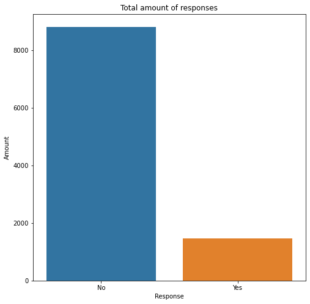

```python
fig, ax = plt.subplots(1,1, figsize=(8,8))
sns.countplot(x='Response', data=new_customer_data)
ax.set_ylabel('Amount')
ax.set_title('Total amount of responses')
plt.show()
```

**Total number of responses by sales channel**

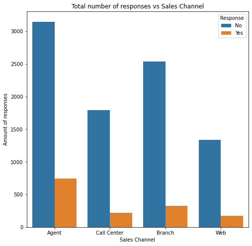

```python
fig, ax = plt.subplots(1,1, figsize=(8,8))
sns.countplot(x='Sales Channel', hue='Response', data=new_customer_data)
ax.set_ylabel('Amount of responses')
ax.set_title('Total number of responses vs Sales Channel')
plt.show()
```

**Response rate by sales channel**

```python
response_yes = new_customer_data[['Sales Channel', 'Response']][new_customer_data['Response'] == 'Yes']\
    .groupby('Sales Channel').count()
response_yes
```

| Sales Channel | Response |
| --- | --- |
| Agent | 742 |
| Branch | 326 |
| Call Center | 221 |
| Web | 177 |

```python
response_total = new_customer_data.groupby('Sales Channel').agg({'Response': 'size'})
response_total
```

| Sales Channel | Response |
| --- | --- |
| Agent | 4121 |
| Branch | 3022 |
| Call Center | 2141 |
| Web | 1626 |

```python
response_rate_channel = response_yes / response_total
response_rate_channel.reset_index(inplace=True)
response_rate_channel.rename(columns={'Response': 'Response Rate'}, inplace=True)
response_rate_channel
```

|  | Sales Channel | Response Rate |
| --- | --- | --- |
| 0 | Agent | 0.180053 |
| 1 | Branch | 0.107876 |
| 2 | Call Center | 0.103223 |
| 3 | Web | 0.108856 |

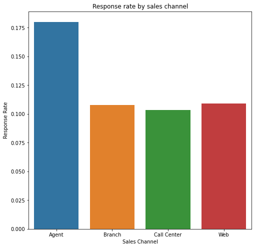

```python
fig, ax = plt.subplots(1,1, figsize=(8,8))
sns.barplot(x='Sales Channel', y='Response Rate', data=response_rate_channel)
ax.set_title('Response rate by sales channel')
plt.show()
```

**Total number of responses by total claim amount**

As there are too many values in the Total Claim Amount column, it makes sense to group the data before plotting them.

```python
labels=['Low', 'Medium', 'High']
claim_amount_binned = pd.qcut(new_customer_data['Total Claim Amount'], q=3, labels=labels)
response_claim = pd.concat([new_customer_data['Response'], claim_amount_binned], axis=1)
response_claim
```

|  | Response | Total Claim Amount |
| --- | --- | --- |
| 0 | No | Low |
| 1 | No | High |
| 2 | No | Medium |
| 3 | Yes | Medium |
| 4 | No | High |
| ... | ... | ... |
| 10905 | No | High |
| 10906 | No | Low |
| 10907 | No | Medium |
| 10908 | No | High |
| 10909 | NaN | High |

10910 rows × 2 columns

```python
bins=['(0.098, 312.0]', '(312.0, 494.4]', '(494.4, 2893.24]']
pd.DataFrame({'bins': bins, 'labels': labels})
```

|  | bins | labels |
| --- | --- | --- |
| 0 | (0.098, 312.0] | Low |
| 1 | (312.0, 494.4] | Medium |
| 2 | (494.4, 2893.24] | High |

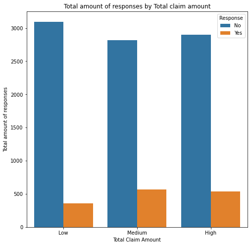

```python
fig, ax = plt.subplots(1,1, figsize=(8,8))
sns.countplot(x='Total Claim Amount', hue='Response', data=response_claim)
ax.set_ylabel('Total amount of responses')
ax.set_title('Total amount of responses by Total claim amount')
plt.show()
```

**Total number of responses by income**

Like in the previous step, we should group the data in Income before plotting.

```python
income_binned = pd.qcut(new_customer_data['Income'], q=3, labels=labels)
response_income = pd.concat([new_customer_data['Response'], income_binned], axis=1)
response_income
```

|  | Response | Income |
| --- | --- | --- |
| 0 | No | Medium |
| 1 | No | Low |
| 2 | No | Medium |
| 3 | Yes | Medium |
| 4 | No | Medium |
| ... | ... | ... |
| 10905 | No | Low |
| 10906 | No | High |
| 10907 | No | Medium |
| 10908 | No | High |
| 10909 | NaN | Low |

10910 rows × 2 columns

```python
income_bins=['(-0.001, 21353.0]', '(21353.0, 52799.667]', '(52799.667, 99981.0]']
pd.DataFrame({'bins': income_bins, 'labels': labels})
```

|  | bins | labels |
| --- | --- | --- |
| 0 | (-0.001, 21353.0] | Low |
| 1 | (21353.0, 52799.667] | Medium |
| 2 | (52799.667, 99981.0] | High |

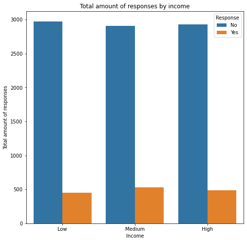

```python
fig, ax = plt.subplots(1,1, figsize=(8,8))
sns.countplot(x='Income', hue='Response', data=response_income)
ax.set_ylabel('Total amount of responses')
ax.set_title('Total amount of responses by income')
plt.show()
```

**Categorical vs numerical**

Let's split the data into numerical and categorical columns to proceed with the analysis.

```python
categoricals = new_customer_data.select_dtypes(include='object')
categoricals
```

|  | State | Response | Coverage | Education | Effective To Date | EmploymentStatus | Gender | Location Code | Marital Status | Policy Type | Policy | Renew Offer Type | Sales Channel | Vehicle Class | Vehicle Size |
| --- | --- | --- | --- | --- | --- | --- | --- | --- | --- | --- | --- | --- | --- | --- | --- |
| 0 | Arizona | No | Basic | College | 2/18/11 | Employed | M | Suburban | Married | Corporate Auto | Corporate L3 | Offer3 | Agent | Four-Door Car | Medsize |
| 1 | California | No | Basic | College | 1/18/11 | Unemployed | F | Suburban | Single | Personal Auto | Personal L3 | Offer4 | Call Center | Four-Door Car | Medsize |
| 2 | Washington | No | Basic | Bachelor | 2/10/11 | Employed | M | Suburban | Single | Personal Auto | Personal L3 | Offer3 | Call Center | SUV | Medsize |
| 3 | Oregon | Yes | Extended | College | 1/11/11 | Employed | M | Suburban | Single | Corporate Auto | Corporate L3 | Offer2 | Branch | Four-Door Car | Medsize |
| 4 | Oregon | No | Premium | Bachelor | 1/17/11 | Medical Leave | F | Suburban | Married | Personal Auto | Personal L2 | Offer1 | Branch | Four-Door Car | Medsize |
| ... | ... | ... | ... | ... | ... | ... | ... | ... | ... | ... | ... | ... | ... | ... | ... |
| 10905 | Nevada | No | Premium | Bachelor | 1/19/11 | Unemployed | F | Suburban | Married | Personal Auto | Personal L1 | Offer3 | Web | Luxury Car | Medsize |
| 10906 | Oregon | No | Basic | College | 1/6/11 | Employed | F | Urban | Married | Personal Auto | Personal L3 | Offer2 | Branch | Four-Door Car | Medsize |
| 10907 | Arizona | No | Extended | Bachelor | 2/6/11 | Employed | F | Rural | Married | Corporate Auto | Corporate L3 | Offer1 | Web | Luxury SUV | Medsize |
| 10908 | California | No | Premium | College | 2/13/11 | Employed | F | Urban | Divorced | Personal Auto | Personal L1 | Offer1 | Branch | SUV | Medsize |
| 10909 | NaN | NaN | Basic | Bachelor | 1/8/11 | Unemployed | M | Suburban | Single | Personal Auto | Personal L1 | Offer4 | Web | SUV | Medsize |

10910 rows × 15 columns

```python
numericals = new_customer_data.select_dtypes(include='number')
numericals
```

|  | Customer Lifetime Value | Income | Monthly Premium Auto | Months Since Last Claim | Months Since Policy Inception | Number of Open Complaints | Number of Policies | Total Claim Amount |
| --- | --- | --- | --- | --- | --- | --- | --- | --- |
| 0 | 4809.216960 | 48029 | 61 | 7.0 | 52 | 0.0 | 9 | 292.800000 |
| 1 | 2228.525238 | 0 | 64 | 3.0 | 26 | 0.0 | 1 | 744.924331 |
| 2 | 14947.917300 | 22139 | 100 | 34.0 | 31 | 0.0 | 2 | 480.000000 |
| 3 | 22332.439460 | 49078 | 97 | 10.0 | 3 | 0.0 | 2 | 484.013411 |
| 4 | 9025.067525 | 23675 | 117 | NaN | 31 | NaN | 7 | 707.925645 |
| ... | ... | ... | ... | ... | ... | ... | ... | ... |
| 10905 | 15563.369440 | 0 | 253 | NaN | 40 | NaN | 7 | 1214.400000 |
| 10906 | 5259.444853 | 61146 | 65 | 7.0 | 68 | 0.0 | 6 | 273.018929 |
| 10907 | 23893.304100 | 39837 | 201 | 11.0 | 63 | 0.0 | 2 | 381.306996 |
| 10908 | 11971.977650 | 64195 | 158 | 0.0 | 27 | 4.0 | 6 | 618.288849 |
| 10909 | 6857.519928 | 0 | 101 | 31.0 | 1 | 0.0 | 3 | 1021.719397 |

10910 rows × 8 columns

**Heatmap**

Let's check the correlation between pairs of numerical variables.

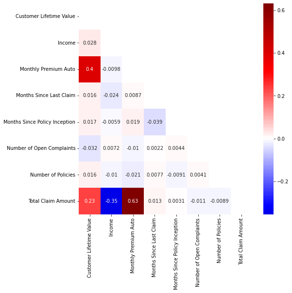

```python
corr = numericals.corr() # returns a dataframe with the correlation values
matrix = np.triu(corr) # sets all the values of the lower triangle (under the main diagonal) to 0 (= False)

fig, ax = plt.subplots(1,1, figsize=(8,8))

sns.heatmap(
    numericals.corr(),  # the data for the heatmap
    annot=True,  # show the actual values of correlation
    cmap='seismic',  # provide the 'seismic' colormap
    center=0,  # specify the value at which to center the colormap
    fmt='.2g', # specify the format for the annotation
    mask=matrix # hides the values where mask = True (= upper triangle)
           )
plt.show()
```

None of the variables showed a high correlation. The best correlation is between Total Claim Amount and Monthly Premium Auto (0.63). Also, there are no signs of multicollinearity.

**Checking for normality**

We'll plot the distribution of the numeric variables to visually check for normallity.

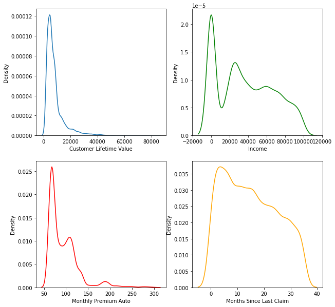

```python
fig, ax = plt.subplots(2, 2, figsize=(10,10))
sns.kdeplot(x='Customer Lifetime Value', data=numericals, ax=ax[0,0])
sns.kdeplot(x='Income', data=numericals, c='green', ax=ax[0,1])
sns.kdeplot(x='Monthly Premium Auto', data=numericals, c='red', ax=ax[1,0])
sns.kdeplot(x='Months Since Last Claim', data=numericals, c='orange', ax=ax[1,1])
plt.show()
```

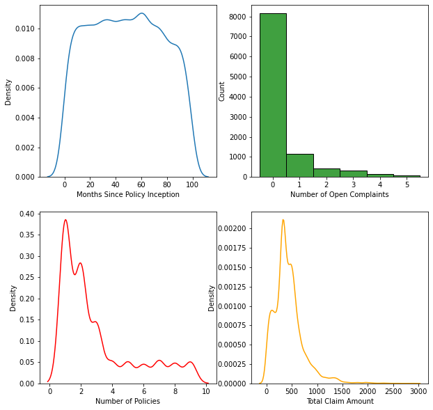

```python
fig, ax = plt.subplots(2, 2, figsize=(10,10))
sns.kdeplot(x='Months Since Policy Inception', data=numericals, ax=ax[0,0])
sns.histplot(x='Number of Open Complaints', data=numericals, color='green', discrete=True, ax=ax[0,1])
sns.kdeplot(x='Number of Policies', data=numericals, c='red', ax=ax[1,0])
sns.kdeplot(x='Total Claim Amount', data=numericals, c='orange', ax=ax[1,1])
plt.show()
```

None of the variables follow a normal distribution.